# Run dmc

Sarah P. Flanagan

February 21, 2018

First I’ll set up the working environment.

```r
source("../../gwscaR/R/gwscaR.R")
source("../../gwscaR/R/gwscaR_plot.R")
source("../../gwscaR/R/gwscaR_utility.R")
source("../../gwscaR/R/gwscaR_fsts.R")
source("../../gwscaR/R/gwscaR_popgen.R")
library(knitr)
library(fields)
library(MASS)
```

and load the necessary files

```r
vcf<-parse.vcf("stacks/p4.vcf") #this is the smaller dataset
```

```r
vcf$SNP<-paste(vcf$`#CHROM`,vcf$POS,sep=".")
scaffs<-levels(as.factor(vcf[,1]))
scaffs[1:22]<-lgs
scaff.starts<-tapply(vcf$POS,vcf$`#CHROM`,max)
scaff.starts<-data.frame(rbind(cbind(names(scaff.starts),scaff.starts)),stringsAsFactors = F)
locus.info<-c(colnames(vcf[1:9]),"SNP")
```

Now I’ll go through the steps outline in https://github.com/kristinmlee/dmc/blob/master/dmc_example.md

## Calculate neutral F matrix

For this first step (calculating the neutral variance/covariance matrix, F), I’ll use LG6, LG11, LG16, and LG20, which have no or few shared outlier loci. I need to (1) Calculate allele frequencies for each population, (2) specify a vector of sample sizes for each population, and (3) specify a string for filename for output.

```r
calc.allFreqs<-function(vcf,pop.list, pop.labs){
  allFreqs<-do.call(rbind,lapply(pop.list, function(pop){
    this.vcf<-cbind(vcf[,1:9],vcf$SNP,vcf[,grep(pop,colnames(vcf))])
    afs<-do.call(rbind,apply(this.vcf,1,calc.afs.vcf))
    return(afs$RefFreq)
  }))
  colnames(allFreqs)<-vcf$SNP
  rownames(allFreqs)<-pop.labs
  return(allFreqs)
}
#calculate selected allele frequencies
LG8<-calc.allFreqs(vcf[vcf$`#CHROM` == "LG8",],pop.list,pop.labs)
saveRDS(LG8,"dmc/selectedRegionAlleleFreqs_p4LG8.RDS")

#calculate neutral allele frequencies
LG6<-calc.allFreqs(vcf[vcf$`#CHROM` == "LG6",],pop.list,pop.labs)
LG11<-calc.allFreqs(vcf[vcf$`#CHROM` == "LG11",],pop.list,pop.labs)
LG16<-calc.allFreqs(vcf[vcf$`#CHROM` == "LG16",],pop.list,pop.labs)
LG20<-calc.allFreqs(vcf[vcf$`#CHROM` == "LG20",],pop.list,pop.labs)
allFreqs <- cbind(LG6, LG11, LG16, LG20) #combine the neutral chroms

sampleSizes<-unlist(lapply(pop.list,function(pop){
  n<-length(grep(pop,colnames(vcf)))
  return(2*n) }))

#other parameters that will be necessarily later on
numPops = 16
M = numPops
Tmatrix = matrix(data = rep(-1 / M, (M - 1) * M), nrow = M - 1, ncol = M)
diag(Tmatrix) = (M - 1) / M

sampleErrorMatrix = diag(1/sampleSizes, nrow = numPops, ncol = numPops)
```

Once those are specified, I can calculate the neutral F matrix, in addition to its determinant and inverse.

```r
neutralF_filename<-"./dmc/neutralF_p4LG8"
source("../programs/dmc-master/calcNeutralF.R")
det_FOmegas_neutral = det(Tmatrix %*% (F_estimate + sampleErrorMatrix) %*% t(Tmatrix))
saveRDS(det_FOmegas_neutral, "dmc/det_FOmegas_neutral_p4LG8.RDS")

inv_FOmegas_neutral = ginv(Tmatrix %*% (F_estimate + sampleErrorMatrix) %*% t(Tmatrix))
saveRDS(inv_FOmegas_neutral, "dmc/inv_FOmegas_neutral_p4LG8.RDS")
```

Let’s look at the allele frequencies on LG8. This will help inform the hypotheses I test with dmc.

```r
stacks.sig<-read.delim("p4.stacks.sig.snps.txt")
stacks.sig$SNP<-paste(stacks.sig$Chr,(stacks.sig$BP+1),sep=".")
LG8[rownames(LG8) %in% c("FLFW","ALFW","LAFW","TXFW"),colnames(LG8) %in% stacks.sig$SNP]
```

```
##      LG8.2652635 LG8.2850670 LG8.3906610 LG8.4317822 LG8.6152745
## TXFW  0.02941176   0.0000000    1.000000   1.0000000           1
## LAFW  0.69230769   0.1666667    1.000000   0.9696970           1
## ALFW  0.30000000   0.0000000    0.984375   0.9791667           1
## FLFW  0.00000000   1.0000000    0.640625   1.0000000           0
##      LG8.6172054 LG8.6742115 LG8.7093319 LG8.7220428 LG8.7622896
## TXFW   1.0000000     1.00000   1.0000000   0.9814815  0.04166667
## LAFW   0.9814815     1.00000   0.9705882   1.0000000  0.34375000
## ALFW   0.9655172     0.96875   1.0000000   1.0000000  0.15789474
## FLFW   1.0000000     1.00000   1.0000000   1.0000000  0.72222222
##      LG8.7918664 LG8.8496641 LG8.9873816 LG8.10070603
## TXFW           1           1   0.8043478    1.0000000
## LAFW           1           1   0.8125000    0.9750000
## ALFW           1           1   0.8250000    0.9852941
## FLFW           0           1   1.0000000    1.0000000
```

```r
LG8[rownames(LG8) %in% c("FLFW","ALFW","LAFW","TXFW"),
         which(colnames(LG8) %in% stacks.sig$SNP)[1]:
           which(colnames(LG8) %in% stacks.sig$SNP)[length(which(colnames(LG8) %in% stacks.sig$SNP))]]
```

```
##      LG8.2652635 LG8.2699493 LG8.2723048 LG8.2768212 LG8.2828714
## TXFW  0.02941176  1.00000000   0.0000000   1.0000000        1.00
## LAFW  0.69230769  0.94000000   0.5000000   0.9230769        0.88
## ALFW  0.30000000  1.00000000   0.6666667   0.9864865        0.96
## FLFW  0.00000000  0.04166667   1.0000000   1.0000000        1.00
##      LG8.2839259 LG8.2841316 LG8.2844787 LG8.2848951 LG8.2850670
## TXFW   1.0000000   1.0000000           1         1.0   0.0000000
## LAFW   0.9791667   0.9886364           1         0.5   0.1666667
## ALFW   0.9583333   1.0000000           1         1.0   0.0000000
## FLFW   1.0000000   1.0000000           1         0.0   1.0000000
##      LG8.2857050 LG8.2925500 LG8.2949699 LG8.3002221 LG8.3025706
## TXFW           0           1           1   0.0000000         0.0
## LAFW           1           1           1   0.5500000         0.5
## ALFW           1           1           1   0.2291667         0.0
## FLFW           0           1           1   1.0000000         1.0
##      LG8.3059547 LG8.3187075 LG8.3280373 LG8.3403275 LG8.3421285
## TXFW   1.0000000      1.0000   1.0000000           1           1
## LAFW   0.8571429      1.0000   1.0000000           1           1
## ALFW   1.0000000      1.0000   0.9545455           1           1
## FLFW   1.0000000      0.4375   1.0000000           1           1
##      LG8.3472373 LG8.3479441 LG8.3482017 LG8.3488681 LG8.3540507
## TXFW   0.7083333           1   1.0000000   0.9814815       1.000
## LAFW   0.8636364           1   0.9666667   0.9875000       1.000
## ALFW   0.9230769           1   1.0000000   0.9756098       0.575
## FLFW   0.7638889           0   1.0000000   1.0000000       1.000
##      LG8.3676369 LG8.3713047 LG8.3776412 LG8.3803092 LG8.3851706
## TXFW           1   1.0000000   0.9230769           1   1.0000000
## LAFW           1   0.9857143   0.9000000           1   0.8333333
## ALFW           1   1.0000000   0.9642857           1   0.2800000
## FLFW           1   0.6621622   1.0000000           1   1.0000000
##      LG8.3872031 LG8.3879452 LG8.3897077 LG8.3906610 LG8.3933996
## TXFW           1           1  0.02380952    1.000000   1.0000000
## LAFW           1           1  0.06521739    1.000000   0.3500000
## ALFW           1           1  0.08823529    0.984375   0.6551724
## FLFW           1           0  1.00000000    0.640625   1.0000000
##      LG8.3947113 LG8.3951824 LG8.3960103 LG8.3989537 LG8.4008144
## TXFW   1.0000000  0.02173913   1.0000000   0.9807692   0.9523810
## LAFW   0.9464286  0.14516129   0.9583333   1.0000000   0.0000000
## ALFW   0.8863636  0.15625000   0.9782609   0.9677419   0.6000000
## FLFW   1.0000000  1.00000000   1.0000000   1.0000000   0.4705882
```

[output cut: 170 more lines]

```
##      LG8.9572915 LG8.9616988 LG8.9617039 LG8.9686452 LG8.9717930
## TXFW           0   1.0000000           0           1         0.0
## LAFW           1   1.0000000           0           1         0.5
## ALFW           1   0.9736842           0           1         1.0
## FLFW           1   1.0000000           1           1         1.0
##      LG8.9759493 LG8.9808193 LG8.9828862 LG8.9851872 LG8.9867124
## TXFW           1   1.0000000   0.7962963           1   1.0000000
## LAFW           1   0.9761905   0.1666667           1   0.9666667
## ALFW           1   0.9756098   0.1481481           1   1.0000000
## FLFW           1   1.0000000   1.0000000           0   1.0000000
##      LG8.9873816 LG8.9965977 LG8.9980275 LG8.9985017 LG8.10070603
## TXFW   0.8043478           1   1.0000000           1    1.0000000
## LAFW   0.8125000           1   0.9500000           1    0.9750000
## ALFW   0.8250000           1   0.9852941           1    0.9852941
## FLFW   1.0000000           0   0.0000000           1    1.0000000
```

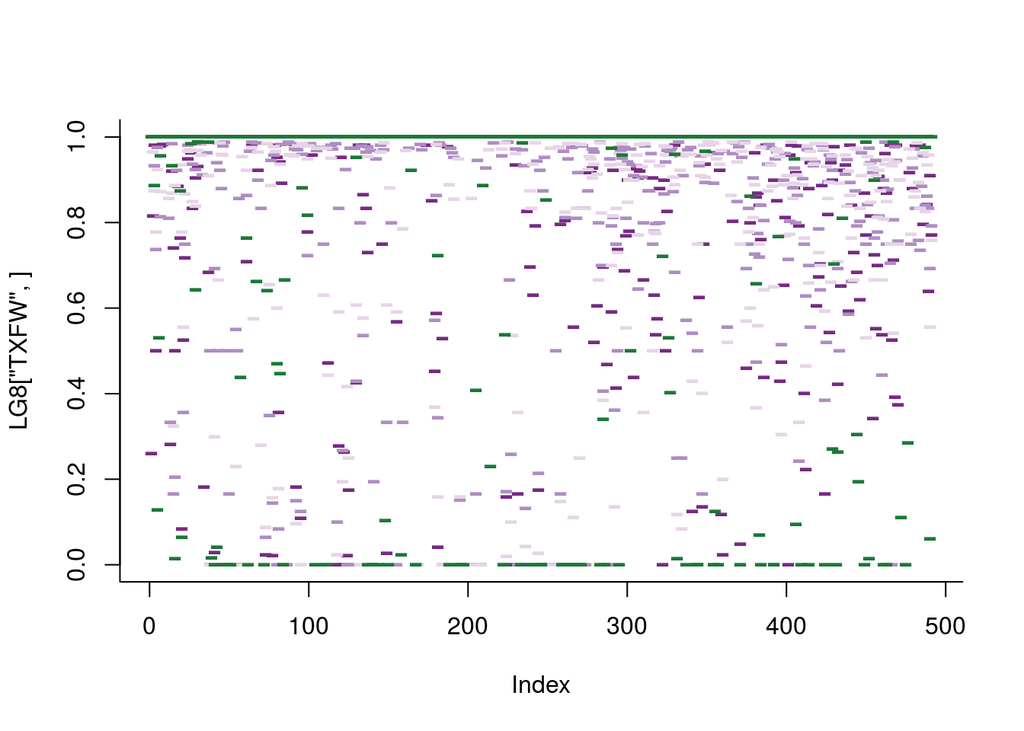

```r
grp.colors<-c('#762a83','#af8dc3','#e7d4e8','#d9f0d3','#7fbf7b','#1b7837')
plot(LG8["TXFW",],col=grp.colors[1],pch="-",bty="L",lwd=2,cex=2)
points(LG8["LAFW",],col=grp.colors[2],pch="-",bty="L",lwd=2,cex=2)
points(LG8["ALFW",],col=grp.colors[3],pch="-",bty="L",lwd=2,cex=2)
points(LG8["FLFW",],col=grp.colors[6],pch="-",bty="L",lwd=2,cex=2)
```

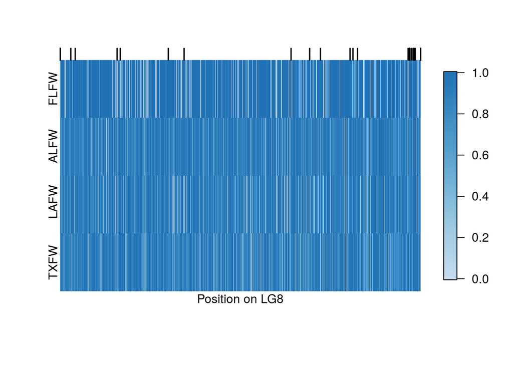

```r
cols<-colorRampPalette(t(brewer.pal(9,name="Blues")[3:7]))(100)

fields::image.plot(t(allFreqs[rownames(allFreqs) %in% c("FLFW","ALFW","LAFW","TXFW"),]),col=cols,
      axes=FALSE)
text(x=-0.02,y=1,"FLFW",srt=90,xpd=TRUE)
text(x=-0.02,y=0.67,"ALFW",srt=90,xpd=TRUE)
text(x=-0.02,y=0.35,"LAFW",srt=90,xpd=TRUE)
text(x=-0.02,y=0,"TXFW",srt=90,xpd=TRUE)
mtext("Position on LG8",1)
axis(3,at =t(LG8[rownames(LG8) %in% c("FLFW","ALFW","LAFW","TXFW"),colnames(LG8) %in% stacks.sig$SNP]),
     labels = FALSE,lwd=0,lwd.ticks = 1.75,tck=-.05)
```

This shows that the FLFW site has somewhat different allele frequencies than the other sites. This suggests that I should test to see whether there was an independent mutation in the FLFW population and the other three have a single sweep.

## Calculate F<sup>(S)</sup> matrices

We generate matrices for the following five models: *1. All selected pops have independent mutations of beneficial allele* 2. All selected pops share beneficial allele via migration *3. Beneficial allele was standing the ancestor of all selected pops* 4. There was an independent mutation in FLFW and the other three share a sweep. *5. FLFW has an independent mutation and the others share a beneficial allele via standing variation

```r
rec <- 0.005 #per base pair recombination rate estimate for the region
Ne <- 10000
numPops <- 16
selPops <- c(3,5,7,16)
numBins <- 1000

F_estimate <- readRDS("./dmc/LG8neutralF.RDS")

positions <-vcf[vcf$`#CHROM`=="LG8","POS"]
saveRDS(positions,"dmc/selectedRegionPositions_p4LG8.RDS")

selSite = seq(min(positions), max(positions), length.out = 10)
sels = c(1e-4, 1e-3, 0.01, seq(0.02, 0.14, by = 0.01), seq(0.15, 0.3, by = 0.05),
         seq(0.4, 0.6, by = 0.1))
times = c(0, 5, 25, 50, 100, 500, 1000, 1e4, 1e6)
gs = c(1/(2*Ne), 10^-(4:1))
migs = c(10^-(seq(5, 1, by = -2)), 0.5, 1)
sources = selPops

source("../programs/dmc-master/genSelMatrices_individualModes.R")
```

### Model 1: all selected populations have independent mutations

```r
FOmegas_ind = lapply(sels, function(sel) {
  calcFOmegas_indSweeps(sel)
})

saveRDS(FOmegas_ind, "dmc/FOmegas_ind_p4LG8.RDS")
#determinant
det_FOmegas_ind = lapply(FOmegas_ind, function(sel) {
    lapply(sel, function(dist) {
        det(dist)
    })
})
saveRDS(det_FOmegas_ind, "dmc/det_FOmegas_ind_p4LG8.RDS")
#inverse
inv_FOmegas_ind = lapply(FOmegas_ind, function(sel) {
    lapply(sel, function(dist) {
        ginv(dist)
    })
})
saveRDS(inv_FOmegas_ind, "dmc/inv_FOmegas_ind_p4LG8.RDS")
```

### Model 2: all selected populations share a beneficial allele via migration

```r
FOmegas_mig = lapply(sels ,function(sel) {
  lapply(migs, function(mig) {
    lapply(sources, function(my.source) {
      calcFOmegas_mig(sel, mig, my.source)
    })
  })
})

saveRDS(FOmegas_mig, "dmc/FOmegas_mig_p4LG8.RDS")
#determinant
det_FOmegas_mig = lapply(FOmegas_mig, function(sel) {
    lapply(sel, function(mig) {
        lapply(mig, function(source) {
            lapply(source, function(dist) {
                det(dist)
            })
        })
    })
})
saveRDS(det_FOmegas_mig, "dmc/det_FOmegas_mig_p4LG8.RDS")
#inverse
inv_FOmegas_mig = lapply(FOmegas_mig, function(sel) {
    lapply(sel, function(mig) {
        lapply(mig, function(source) {
            lapply(source, function(dist) {
                ginv(dist)
            })
        })
    })
})
saveRDS(inv_FOmegas_mig, "dmc/inv_FOmegas_mig_p4LG8.RDS")
```

### Model 3: beneficial allele was standing in the ancestor of all selected populations

```r
FOmegas_sv = lapply(sels, function(sel) {
  lapply(gs, function(g) {
    lapply(times, function(time) {
      lapply(sources, function(my.source) {
        calcFOmegas_stdVar.source(sel, g, time, my.source)
      })
    })
  })
})

saveRDS(FOmegas_sv, "dmc/FOmegas_sv_p4LG8.RDS")
#determinant
det_FOmegas_sv = lapply(FOmegas_sv, function(sel) {
    lapply(sel, function(g) {
        lapply(g, function(time) {
            lapply(time, function(my.source) {
                lapply(my.source, function(dist) {
                    det(dist)
                })
            })
        })
    })
})
saveRDS(det_FOmegas_sv, "dmc/det_FOmegas_sv_p4LG8.RDS")
#inverse
inv_FOmegas_sv = lapply(FOmegas_sv, function(sel) {
    lapply(sel, function(g) {
        lapply(g, function(time) {
            lapply(time, function(my.source) {
                lapply(my.source, function(dist) {
                    ginv(dist)
                })
            })
        })
    })
})
saveRDS(inv_FOmegas_sv, "dmc/inv_FOmegas_sv_p4LG8.RDS")
```

### Model 4: FLFW has an independent mutation but the others share a beneficial allele via migration

```r
sets<-list(c(3,5,7),16)
source("../programs/dmc-master/genSelMatrices_multipleModes.R")

my.modes_migInd=c("mig","ind")

#the parameters time and g are not involved in the migration model so we only loop over
## the first element of these vectors
FOmegas_mixed_migInd = lapply(sels ,function(sel) {
    lapply(gs[1], function(g) {
        lapply(times[1], function(time) {
            lapply(migs, function(mig) {
                lapply(sources, function(my.source) {
                    calcFOmegas_mixed(sel, g, time, mig, my.source, my.modes_migInd)
                })
            })
        })
    })
})

saveRDS(FOmegas_mixed_migInd, "dmc/FOmegas_mixed_migInd_p4LG8.RDS")

detFOmegas_mixed_migInd = lapply(FOmegas_mixed_migInd, function(sel) {
    lapply(sel, function(g) {
        lapply(g, function(time) {
            lapply(time, function(mig) {
                lapply(mig, function(source) {
                    lapply(source, function(dist) {
                        det(dist)
                    })
                })
            })
        })
    })
})
saveRDS(detFOmegas_mixed_migInd, "dmc/det_FOmegas_mixed_migInd_p4LG8.RDS")

invFOmegas_mixed_migInd = lapply(FOmegas_mixed_migInd, function(sel) {
    lapply(sel, function(g) {
        lapply(g, function(time) {
            lapply(time, function(mig) {
                lapply(mig, function(source) {
                    lapply(source, function(dist) {
                        ginv(dist)
                    })
                })
            })
        })
    })
})
saveRDS(invFOmegas_mixed_migInd, "dmc/inv_FOmegas_mixed_migInd_p4LG8.RDS")
```

### Model 5: FLFW has an independent mutation and the others share a beneficial allele via standing variation

I’m running this one on abies using `nohup Rscript ~/Projects/popgen/scripts/dmc_model5.R > ~/Projects/popgen/dmc5.log 2>&1 &`. It’s process 54368 (finished on Feb 19).

```r
my.modes_svInd = c("sv", "ind")

#the parameter mig is not involved in the standing variant model so we only loop over
## the first element of this vector
FOmegas_mixed_svInd = lapply(sels ,function(sel) {
    lapply(gs, function(g) {
        lapply(times, function(time) {
            lapply(migs[1], function(mig) {
                lapply(sources, function(my.source) {
                    calcFOmegas_mixed(sel, g, time, mig, my.source, my.modes_svInd)
                })
            })
        })
    })
})

saveRDS(FOmegas_mixed_svInd, "dmc/FOmegas_mixed_svInd_p4LG8.RDS")

detFOmegas_mixed_svInd = lapply(FOmegas_mixed_svInd, function(sel) {
    lapply(sel, function(g) {
        lapply(g, function(time) {
            lapply(time, function(mig) {
                lapply(mig, function(source) {
                    lapply(source, function(dist) {
                        det(dist)
                    })
                })
            })
        })
    })
})
saveRDS(detFOmegas_mixed_svInd, "dmc/det_FOmegas_mixed_svInd_p4LG8.RDS")

invFOmegas_mixed_svInd = lapply(FOmegas_mixed_svInd, function(sel) {
    lapply(sel, function(g) {
        lapply(g, function(time) {
            lapply(time, function(mig) {
                lapply(mig, function(source) {
                    lapply(source, function(dist) {
                        ginv(dist)
                    })
                })
            })
        })
    })
})
saveRDS(invFOmegas_mixed_svInd, "dmc/inv_FOmegas_mixed_svInd_p4LG8.RDS")
```

## Calculate composite likelihoods

Now we need to calculate composite likelihoods, which includes knowing how far away we are from the proposed selected site.

The inverses and determinants generated above can be used to calculate the log-likelihood of a site a given distance away from a proposed selected site. To do this, we sum the log-likelihoods across all SNPs in the window to obtain a ocmposite log-likelihood under a given convergence model with a set of parameters for a proposed selected site.

First, we randomize with respect to the reference allele. [where did these selected region allele freqs come from?]

```r
freqs_notRand = readRDS("dmc/selectedRegionAlleleFreqs_p4LG8.RDS")

randFreqs = apply(freqs_notRand, 2, function(my.freqs) {
    if(runif(1) < 0.5) {
        my.freqs = 1 - my.freqs
    }
    my.freqs
})

saveRDS(randFreqs, "dmc/selectedRegionAlleleFreqsRand_p4LG8.RDS")
```

```r
freqs<-readRDS("dmc/selectedRegionAlleleFreqsRand_p4LG8.RDS")
positions<-readRDS("dmc/selectedRegionPositions_p4LG8.RDS")

#these are the same as above
numPops <- 16
numBins <- 1000


rec <- 0.005 #per base pair recombination rate estimate for the region

selSite = seq(min(positions), max(positions), length.out = 10)
sels = c(1e-4, 1e-3, 0.01, seq(0.02, 0.14, by = 0.01), seq(0.15, 0.3, by = 0.05),
         seq(0.4, 0.6, by = 0.1)) #possible selection coefficients
times = c(0, 5, 25, 50, 100, 500, 1000, 1e4, 1e6)
Ne <- 10000
gs = c(1/(2*Ne), 10^-(4:1))
migs = c(10^-(seq(5, 1, by = -2)), 0.5, 1)
selPops <- c(3,5,7,16)
sources = selPops
```

```r
source("../programs/dmc-master/calcCompositeLike.R")

## Neutral model
det_FOmegas_neutral = readRDS("dmc/det_FOmegas_neutral_p4LG8.RDS")
inv_FOmegas_neutral = readRDS("dmc/inv_FOmegas_neutral_p4LG8.RDS")
compLikelihood_neutral = lapply(1 : length(selSite), function(j) {
  calcCompLikelihood_neutral(j, det_FOmegas_neutral, inv_FOmegas_neutral)
})
saveRDS(compLikelihood_neutral, "dmc/compLikelihood_neutral_p4LG8.RDS")

## Model 1
det_FOmegas_ind = readRDS("dmc/det_FOmegas_ind_p4LG8.RDS")
inv_FOmegas_ind = readRDS("dmc/inv_FOmegas_ind_p4LG8.RDS")
compLikelihood_ind = lapply(1 : length(selSite), function(j) {
  lapply(1 : length(sels), function(sel) calcCompLikelihood_1par(j, det_FOmegas_ind,
                                                                 inv_FOmegas_ind, sel))
})
saveRDS(compLikelihood_ind, "dmc/compLikelihood_ind_p4LG8.RDS")

## Model 2
det_FOmegas_mig = readRDS("dmc/det_FOmegas_mig_p4LG8.RDS")
inv_FOmegas_mig = readRDS("dmc/inv_FOmegas_mig_p4LG8.RDS")
compLikelihood_mig = lapply(1 : length(selSite), function(j) {
    lapply(1 : length(sels), function(sel) {
        lapply(1 : length(migs), function(mig) {
            lapply(1 : length(sources), function(my.source) {
                calcCompLikelihood_3par(j, det_FOmegas_mig, inv_FOmegas_mig, sel, mig,
                                        my.source)
            })
        })
    })
})
saveRDS(compLikelihood_mig, "dmc/compLikelihood_mig_p4LG8.RDS")

## Model 3
det_FOmegas_sv = readRDS("dmc/det_FOmegas_sv_p4LG8.RDS")
inv_FOmegas_sv = readRDS("dmc/inv_FOmegas_sv_p4LG8.RDS")
compLikelihood_sv = lapply(1 : length(selSite), function(j) {
    lapply(1 : length(sels), function(sel) {
        lapply(1 : length(gs), function(g) {
            lapply(1 : length(times), function(t) {
                lapply(1: length(sources), function(my.source) {
                calcCompLikelihood_4par(j, det_FOmegas_sv, inv_FOmegas_sv, sel, g, t,
                                        my.source)
                })
            })
        })
    })
})
saveRDS(compLikelihood_sv, "dmc/compLikelihood_sv_p4LG8.RDS")

## Model 4
det_FOmegas_mixed_migInd = readRDS("dmc/det_FOmegas_mixed_migInd_p4LG8.RDS")
inv_FOmegas_mixed_migInd = readRDS("dmc/inv_FOmegas_mixed_migInd_p4LG8.RDS")

# same trick as above (the parameters time and g are not involved in the migration
## model so we only loop over the first element of these vectors)
# now save lists for each proposed selected site (may want to do this for other
## models/more elegantly depending on density of parameter space)
for(j in 1 : length(selSite)) {
    compLikelihood_mixed_migInd = lapply(1 : length(sels), function(sel) {
        lapply(1 : length(gs[1]), function(g) {
            lapply(1 : length(times[1]), function(t) {
              lapply(1 : length(migs), function (mig) {
                  lapply(1: length(sources), function(my.source) {
                    calcCompLikelihood_5par(j, det_FOmegas_mixed_migInd,
                                            inv_FOmegas_mixed_migInd, sel, g, t, mig,
                                            my.source)
                  })
                })
            })
        })
    })
  saveRDS(compLikelihood_mixed_migInd,
          paste("dmc/compLikelihood_mixed_migInd_p4LG8_selSite", j, ".RDS",
                sep = ""))
}

## Model 5
det_FOmegas_mixed_svInd = readRDS("dmc/det_FOmegas_mixed_svInd_p4LG8.RDS")
inv_FOmegas_mixed_svInd = readRDS("dmc/inv_FOmegas_mixed_svInd_p4LG8.RDS")

#same trick as above (the parameter mig is not involved in the migration model so we
##only loop over the first element of this vector)
# now save lists for each proposed selected site (may want to do this for other
## models/more elegantly depending on density of parameter space)
for(j in 1 : length(selSite)) {
    compLikelihood_mixed_svInd = lapply(1 : length(sels), function(sel) {
        lapply(1 : length(gs), function(g) {
            lapply(1 : length(times), function(t) {
              lapply(1 : length(migs[1]), function (mig) {
                  lapply(1: length(sources), function(my.source) {
                    calcCompLikelihood_5par(j, det_FOmegas_mixed_svInd,
                                            inv_FOmegas_mixed_svInd, sel, g, t, mig,
                                            my.source)
                  })
                })
            })
        })
    })
  saveRDS(compLikelihood_mixed_svInd,
          paste("dmc/compLikelihood_mixed_svInd_p4LG8_selSite", j, ".RDS",
                sep = ""))
}
```

Combine files for models 4 and 5 that are separated by proposed selected site.

```r
positions = readRDS("dmc/selectedRegionPositions_p4LG8.RDS")
selSite = seq(min(positions), max(positions), length.out = 10)

## Model 4
compLikelihood_mixed_migInd_all = lapply(1: length(selSite), function(i) {
  readRDS(paste("dmc/compLikelihood_mixed_migInd_p4LG8_selSite", i, ".RDS",
                sep = ""))
})

saveRDS(compLikelihood_mixed_migInd_all, "dmc/compLikelihood_mixed_migInd_p4LG8.RDS")

## Model 5
compLikelihood_mixed_svInd_all = lapply(1: length(selSite), function(i) {
  readRDS(paste("dmc/compLikelihood_mixed_svInd_p4LG8_selSite", i, ".RDS",
                sep = ""))
})

saveRDS(compLikelihood_mixed_svInd_all, "dmc/compLikelihood_mixed_svInd_p4LG8.RDS")
```

## Plot maximum composite likelihood ratios for models over proposed selected sites

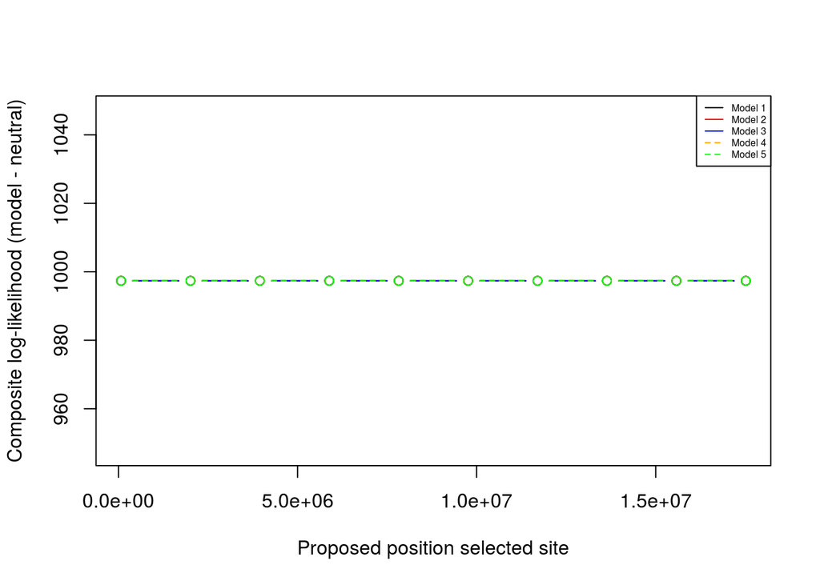

```r
positions = readRDS("dmc/selectedRegionPositions_p4LG8.RDS")
selSite = seq(min(positions), max(positions), length.out = 10)

#read in composite likelihood files and calculate max for all proposed selected sites
compLikelihood_neutral = readRDS("dmc/compLikelihood_neutral_p4LG8.RDS")
compLikelihood_neutral_site = sapply(1 : length(selSite), function(i) {
  max(unlist(compLikelihood_neutral[[i]]))
})

compLikelihood_ind = readRDS("dmc/compLikelihood_ind_p4LG8.RDS")
compLikelihood_ind_site = sapply(1 : length(selSite), function(i) {
  max(unlist(compLikelihood_ind[[i]]))
})

compLikelihood_mig = readRDS("dmc/compLikelihood_mig_p4LG8.RDS")
compLikelihood_mig_site = sapply(1 : length(selSite), function(i) {
  max(unlist(compLikelihood_mig[[i]]))
})

compLikelihood_sv = readRDS("dmc/compLikelihood_sv_p4LG8.RDS")
compLikelihood_sv_site = sapply(1 : length(selSite), function(i) {
  max(unlist(compLikelihood_sv[[i]]))
})

compLikelihood_mixed_migInd = readRDS("dmc/compLikelihood_mixed_migInd_p4LG8.RDS")
compLikelihood_mixed_migInd_site = sapply(1 : length(selSite), function(i) {
  max(unlist(compLikelihood_mixed_migInd[[i]]))
})

compLikelihood_mixed_svInd = readRDS("dmc/compLikelihood_mixed_svInd_p4LG8.RDS")
compLikelihood_mixed_svInd_site = sapply(1 : length(selSite), function(i) {
  max(unlist(compLikelihood_mixed_svInd[[i]]))
})

plot_range = range(c((compLikelihood_ind_site - compLikelihood_neutral_site),
                     (compLikelihood_mig_site - compLikelihood_neutral_site),
                     (compLikelihood_sv_site - compLikelihood_neutral_site),
                     (compLikelihood_mixed_migInd_site - compLikelihood_neutral_site),
                     (compLikelihood_mixed_svInd_site - compLikelihood_neutral_site)))

plot(selSite, compLikelihood_ind_site - compLikelihood_neutral_site, type = "b",
     ylim = c(plot_range[1] - 50, plot_range[2] + 50),
     xlab = "Proposed position selected site",
     ylab = "Composite log-likelihood (model - neutral)")
lines(selSite, compLikelihood_mig_site - compLikelihood_neutral_site, col = "red",
      type = "b")
lines(selSite, compLikelihood_sv_site - compLikelihood_neutral_site, col = "blue",
      type = "b")
lines(selSite, compLikelihood_mixed_migInd_site - compLikelihood_neutral_site,
      col = "orange", lty = 2, type = "b")
lines(selSite, compLikelihood_mixed_svInd_site - compLikelihood_neutral_site,
      col = "green", lty = 2, type = "b")
legend("topright", col = c("black", "red", "blue", "orange", "green"),
       lty = c(rep(1, 3), rep(2, 2)), sapply(1 : 5, function(i) paste("Model", i)),
       cex = 0.5)
```

### Get maximum composite likelihood estimates

```r
source("../programs/dmc-master/getMCLE.R")

#These won't work if the parameters aren't specified as above

## Model 1
getMCLEind(compLikelihood_ind, selSite, sels)
```

```
##      maxLoc maxSel
## [1,]  71269  1e-04
```

```r
## Model 2
getMCLEmig(compLikelihood_mig, selSite, sels, migs, sources)
```

```
##      maxLoc maxSel maxMig maxSource
## [1,]  71269  1e-04  1e-05         3
```

```r
## Model 3
getMCLEsv_source(compLikelihood_sv, selSite, sels, gs, times, sources)
```

```
##      maxLoc maxSel  maxG maxTime maxSource
## [1,]  71269  1e-04 5e-05       0         3
```

```r
## Model 4
getMCLEmixed(compLikelihood_mixed_migInd, selSite, sels, gs[1], times[1], migs, sources)
```

[output not shown]

```r
## Model 5
getMCLEmixed(compLikelihood_mixed_svInd, selSite, sels, gs, times, migs[1], sources)
```

[output not shown]

### Plot profile likelihood surfaces

Plot the profile likelihood surfaces for the parameter of time the beneficial allele has been standing independently in the selecte dpopulations for the models with the highest composite log-likelihoods.